# Statystyczna Analiza Danych

### Zadanie 3

Na początku chcemy ściągnąć z sieci jakieś dane giełdowe; poniższy sposób jest całkiem wygodny

```r
www <-"https://www.mimuw.edu.pl/~noble/courses/SDA/data/stockexchange.dat"
stockexchange <- read.table(www,header=T)
```

Teraz bierzemy z tego wartość bezwzględną i patrzymy, czy to, co nam wyszło, ma szansę pochodzić z rozkładu normalnego. W tym celu wykorzystujemy funkcję `qqplot`, która rysuje wykres punktów (kwantyl rzeczywisty, kwantyl oczekiwany). Im bardziej ten wykres odbiega od prostej, tym bardziej powinniśmy się niepokoić. Funkcja `qqline` rysuje wspomnianą prostą, natomiast `qqPlot` z pakietu `car` dokłada do tego przedziały ufności; niestety, sam nie mogłem zainstalwać tego pakietu.

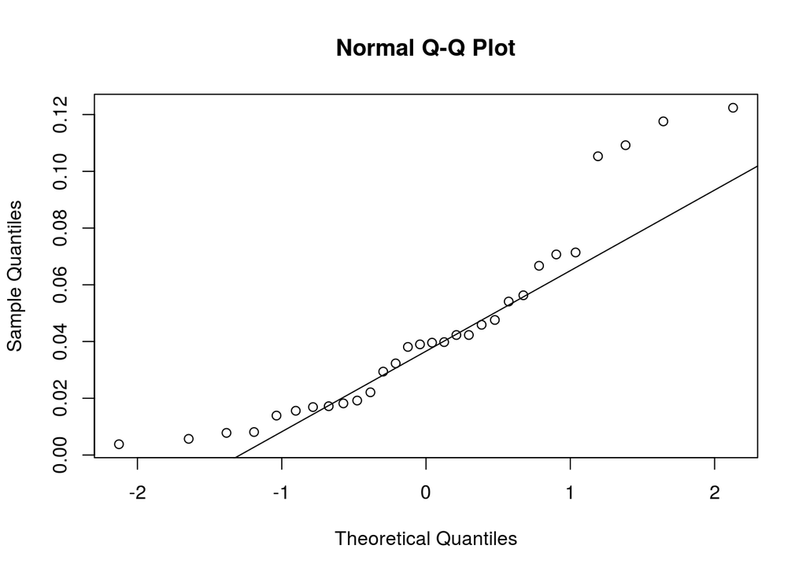

```r
stock2 <- abs(stockexchange)
qqnorm(stock2[,1])
qqline(stock2[,1])
```

```r
# install.packages("car")
# library(car)
# qqPlot(stock2[,1])
```

Wygląda to raczej mało przekonująco…

Możemy również przyrównać histogram otrzymanych wartości do teoretycznej gęstości; w tym celu wykorzystamy funkcję `lines` będącą odpowiednikiem wykorzystanego wcześniej `points`.

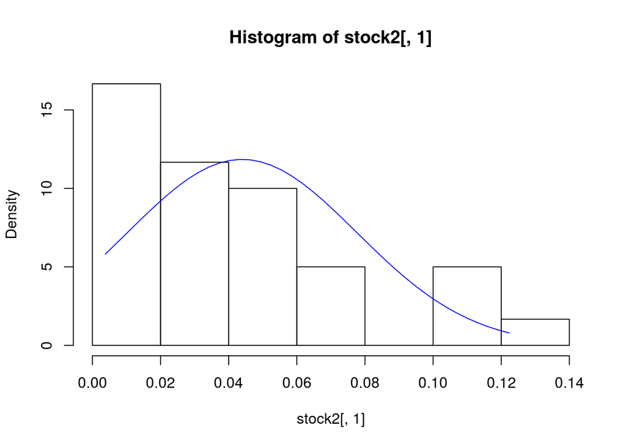

```r
m = mean(stock2[ , 1] )
s = sd(stock2[,1] )
hist(stock2[,1] ,probability = TRUE)

    # dokładam podziałkę osi x
pt <- seq(min(stock2[ , 1] ) ,max(stock2[ , 1] ) , length = 40)
    # ... i rysuję krzywą
lines(pt ,dnorm(pt ,mean=m, sd=s) , col="blue")
```

W swoim skrypcie dr Noble proponuje jeszcze inny sposób na wykonanie tego samego

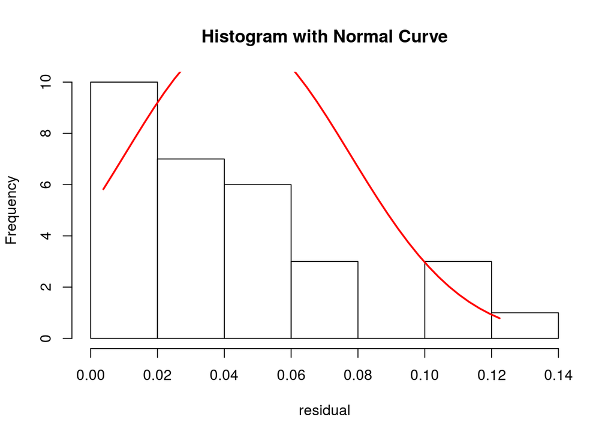

```r
z <- stock2[,1]
h<-hist(z, xlab="residual", main="Histogram with Normal Curve")
xfit<-seq(min(z),max(z),length=40)
yfit<-dnorm(xfit,mean=mean(z),sd=sd(z))
lines(xfit, yfit, col="red", lwd=2)
```

Wydaje się jednak, że coś się zmieniło. **Co i dlaczego?**

A teraz pokazujemy, że umiemy rysować dwa wykresy w ramach jednego obrazka; w tym celu posługujemy się funkcją `par`.

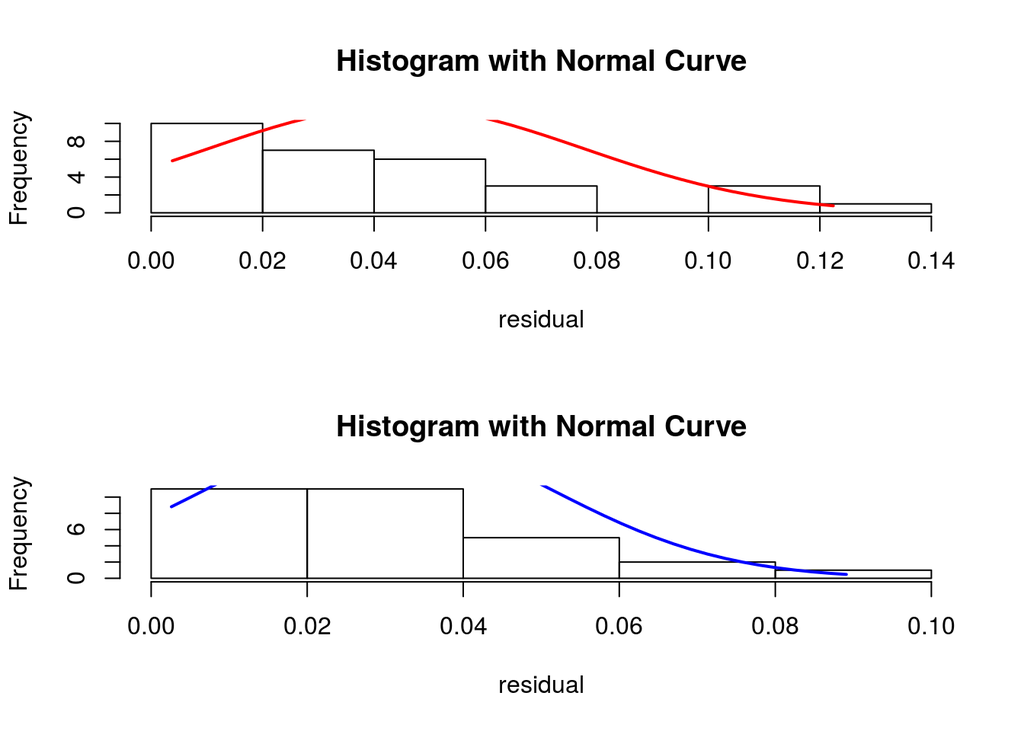

```r
stock2 <- abs(stockexchange)
z <- stock2[,1]
y<-stock2[,2]
par(mfrow=c(2,1))
h<-hist(z, xlab="residual", main="Histogram with Normal Curve")
xfit<-seq(min(z),max(z),length=40)
yfit<-dnorm(xfit,mean=mean(z),sd=sd(z))
lines(xfit, yfit, col="red", lwd=2)
h2<-hist(y, xlab="residual", main="Histogram with Normal Curve")
xfit2<-seq(min(y),max(y),length=40)
yfit2<-dnorm(xfit2,mean=mean(y),sd=sd(y))
lines(xfit2, yfit2, col="blue", lwd=2)
```

Skoro założenie o normalności wyników nie wydało się nam sensowne, to spróbujmy jakoś te wyniki przekształcić…

```r
stocktrans <- log( stock2 + 0.01)
```

Uzyskane w ten sposób wartości wydają się lepiej pasować do rozkładu normalnego.

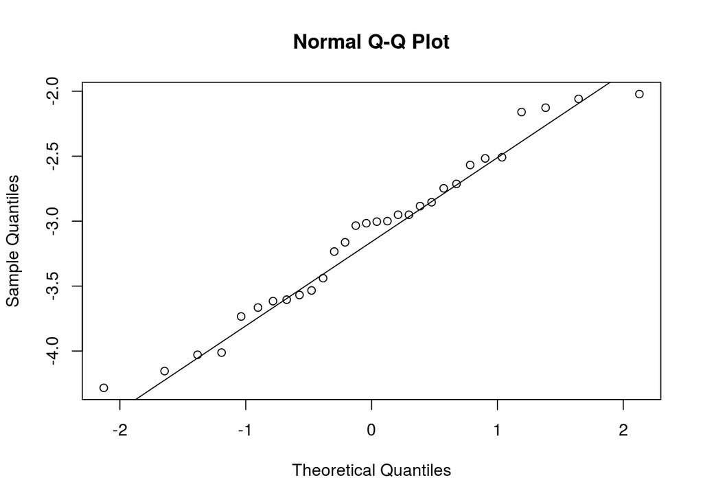

```r
qqnorm(stocktrans[,1])
qqline(stocktrans[,1])
```

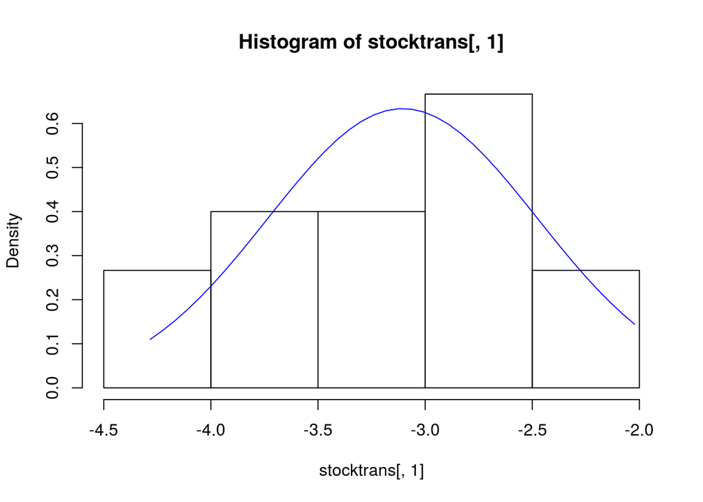

```r
m = mean(stocktrans[ , 1] )
s = sd(stocktrans[,1] )
hist(stocktrans[,1] ,probability = TRUE)
pt <- seq(min(stocktrans[ , 1] ) ,max(stocktrans[ , 1] ) , length = 40)
lines(pt ,dnorm(pt ,mean=m, sd=s) , col="blue")
```

Popatrzmy na wartość oczekiwaną i odchylenie standardowe otrzymanych wartości. W tym celu znowu wykorzystamy funkcję `apply`

```r
s<-apply(stocktrans,2,sd)
s
```

```
##      NASD      NYSE
## 0.6295807 0.5429186
```

```r
m<-apply(stocktrans , 2 ,mean)
m
```

```
##      NASD      NYSE
## -3.105020 -3.384848
```

```r
t.test(stocktrans[ , 1] , stocktrans[, 2] ,var.equal = TRUE, paired = FALSE)
```

```
##
##  Two Sample t-test
##
## data:  stocktrans[, 1] and stocktrans[, 2]
## t = 1.8436, df = 58, p-value = 0.07035
## alternative hypothesis: true difference in means is not equal to 0
## 95 percent confidence interval:
##  -0.02399645  0.58365258
## sample estimates:
## mean of x mean of y
## -3.105020 -3.384848
```

```r
t.test(stocktrans[ , 1] , stocktrans[, 2] , alternative = "greater" ,
       paired = FALSE, var.equal = TRUE, conf.level = 0.95)
```

```
##
##  Two Sample t-test
##
## data:  stocktrans[, 1] and stocktrans[, 2]
## t = 1.8436, df = 58, p-value = 0.03517
## alternative hypothesis: true difference in means is greater than 0
## 95 percent confidence interval:
##  0.02611659        Inf
## sample estimates:
## mean of x mean of y
## -3.105020 -3.384848
```

Pytanie: czy powinniśmy odrzucić naszą hipotezę?

### Zadanie 4

Najpierw próbkujemy z rozkładu normalnego o różnych parametrach

```r
x <- rnorm(10,22,6)
y <- rnorm(31,16,2)
```

Zobaczmy, czy test t-Studenta wykryje różne wartości oczekiwane

```r
t.test(x,y, alternative = "two.sided", paired = FALSE,
       var.equal = FALSE, conf.level = 0.95)
```

```
##
##  Welch Two Sample t-test
##
## data:  x and y
## t = 2.3865, df = 9.5022, p-value = 0.03941
## alternative hypothesis: true difference in means is not equal to 0
## 95 percent confidence interval:
##  0.3031984 9.8540656
## sample estimates:
## mean of x mean of y
##  21.11567  16.03704
```

```r
s1 <- sd(x)
s2 <- sd(y)
m <- 10
n <- 31
f1 <- s1^2/m
f2 <- s2^2/n
eta <- (f1+f2)^2/( f1^2/(m-1)+f2^2/(n-1))
eta
```

```
## [1] 9.502165
```

**Yupikaei, udało się!**

To teraz popatrzymy, co jesteśmy w stonie powiedzieć o wariancjach… W tym celu przeprowadzimy test F-Snedeckora przy użyciu funkcji `var.test`.

```r
var.test(x,y,ratio=1,alternative = "two.sided",conf.level = 0.95)
```

```
##
##  F test to compare two variances
##
## data:  x and y
## F = 11.672, num df = 9, denom df = 30, p-value = 2.552e-07
## alternative hypothesis: true ratio of variances is not equal to 1
## 95 percent confidence interval:
##   4.533507 41.557154
## sample estimates:
## ratio of variances
##           11.67201
```

No to wariancje są raczej rózne. Popatrzmy jeszcze na odpowiedni przedział ufności dla ilorazu:

```r
qf(c(0.025,0.975),9,30)
```

```
## [1] 0.2808665 2.5746101
```

A tak z ciekawości… czym w tym wypadku jest statystyka testowa? :)

```r
s1^2/s2^2
```

```
## [1] 11.67201
```

Sprawdźmy jeszcze, co by było gdybyśmy na samym początku stwierdzili, że wariancje są równe, i wykorzystując tę wiedzę postanowili porównywać wartości oczekiwane:

```r
t.test(x,y, alternative = "two.sided", paired = FALSE,
       var.equal = TRUE, conf.level = 0.95)
```

```
##
##  Two Sample t-test
##
## data:  x and y
## t = 3.8622, df = 39, p-value = 0.0004125
## alternative hypothesis: true difference in means is not equal to 0
## 95 percent confidence interval:
##  2.418903 7.738361
## sample estimates:
## mean of x mean of y
##  21.11567  16.03704
```

Uuu… no to byśmy się nieźle przejechali…

### Zadanie 5

Króciutkie zadanko. Wykonujemy 16 doświadcześ z prawdopodobiestwem sukcesu 0.3, i tak robimy 1000 razy

```r
n<-16
p<-0.3
bindat<-rbinom(1000,n,p)
```

Przypominamy sobie, jak w tym wypadku wyglądają przedziały ufności (**TABLICA**), a następnie sami obliczamy je w eRze…

```r
phat <- bindat/n
lower <- phat - 1.96*sqrt(phat*(1-phat)/n)
upper <- phat + 1.96*sqrt(phat*(1-phat)/n)
```

Patrzymy, ile razy parametr nie trafiłby w przedział ufności. Teoretycznie powinno wyjść około 50, a w praktyce? PS. Warto zwrócić uwagę na konstrukcję `wektor>p`, jest to bardzo pożyteczne.

```r
l <- sum(lower>p)
u<-sum(upper < p)
miss <- l+u
```

```r
n<-80
p<-0.3
bindat<-rbinom(1000,n,p)

phat <- bindat/n
lower <- phat - 1.96*sqrt(phat*(1-phat)/n)
upper <- phat + 1.96*sqrt(phat*(1-phat)/n)
l <- sum(lower>p)
u<-sum(upper < p)
miss <- l+u
```

### Zadanie 6

Przypomnimy sobie, o co chodziło z mocą testu. Jest to funkcja, która dla danego parametru przyporządkowuje prawdopobieństwo odrzucenia hipotezy zerowej przy tym parametrze (czyli jeśli parametr nie należy do hipotezy zerowej, to jest to coś dobrego). Zobaczmy na przykładzie testu t-Studenta.

Najpierw generujemy 1000 razy po 16 próbek

```r
n = 16
N = 1000
X<-matrix(rnorm(n*N,5,1.2),N,n)
```

Dalej obliczamy średnią oraz wariancję, a następnie statystykę testową do t-studenta.

```r
me <- apply(X,1,mean)
s <- apply(X,1,sd)
u<-(me - 5)/(s/sqrt(n))
```

Obliczmy odpowiednią graniczną wartość statystyki i zobaczmy, ile razy ją odrzucimy

```r
tval <-qt(0.975,n-1)
reject0 <- sum(u>tval)+sum(u<(-1)*tval)
reject0/N
```

```
## [1] 0.052
```

W ten sposób uzyskaliśmy moc testu w punkcie 5. Teraz zróbmy to samo, tylko dla średniej równej 6

```r
X<-matrix(rnorm(n*N,6,1.2),N,n)
me <- apply(X,1,mean)
s <- apply(X,1,sd)
u<-(me - 5)/(s/sqrt(n))
tval <-qt(0.975,n-1)
reject1 <- sum(u>tval)+sum(u<(-1)*tval)
reject1/N
```

```
## [1] 0.899
```

Wychodzi przyzwoicie. Popatrzmy jeszcze na odpowiednie przedziały ufności:

```r
binom.test(reject1,1000,conf.level=0.95)
```

```
##
##  Exact binomial test
##
## data:  reject1 and 1000
## number of successes = 899, number of trials = 1000, p-value <
## 2.2e-16
## alternative hypothesis: true probability of success is not equal to 0.5
## 95 percent confidence interval:
##  0.8786332 0.9169799
## sample estimates:
## probability of success
##                  0.899
```

To wszystko mogliśmy zrobić dużo szybciej przy użyciu następującej komendy:

```r
power.t.test(n=16,delta=1,sd=1.2,sig.level=0.05,type = "one.sample",
             alternative="two.sided",strict = TRUE)
```

```
##
##      One-sample t test power calculation
##
##               n = 16
##           delta = 1
##              sd = 1.2
##       sig.level = 0.05
##           power = 0.8756852
##     alternative = two.sided
```